# USING LINEAR REGRESSION TO PREDICT INSURANCE CHARGES

```python
__author__ = "Thien Kim To"
__email__ = "tothienkim312@gmail.com"
__linkedin__ = "https://www.linkedin.com/in/thienkimto/"
```

```python
import numpy as np
import pandas as pd
import matplotlib.pyplot as plt
import seaborn as sns
import sklearn
```

## Part 1 - Introduction 👩‍⚕️

In this project, I am going to analyze health insurance company data to predict future claims and identify factors that influence healthcare costs. The main objective of this project will be the premise for determining the cost of the company's health insurance product. I identified two major research questions that needed to be addressed, namely:

- On what factors do the annual hospital fees paid by health insurance depend, and how do they impact?
- Which predictive model gives the best results?

### Dataset information

Dataset: https://www.kaggle.com/datasets/teertha/ushealthinsurancedataset

"US Health Insurance Dataset" is a public dataset on Kaggle, which can be helpful in a simple yet illuminating study in understanding the risk underwriting in Health Insurance, the interplay of various attributes of the insured and see how they affect the insurance premium.

```python
data = pd.read_csv('insurance.csv')
data
```

|  | age | sex | bmi | children | smoker | region | charges |
| --- | --- | --- | --- | --- | --- | --- | --- |
| 0 | 19 | female | 27.900 | 0 | yes | southwest | 16884.92400 |
| 1 | 18 | male | 33.770 | 1 | no | southeast | 1725.55230 |
| 2 | 28 | male | 33.000 | 3 | no | southeast | 4449.46200 |
| 3 | 33 | male | 22.705 | 0 | no | northwest | 21984.47061 |
| 4 | 32 | male | 28.880 | 0 | no | northwest | 3866.85520 |
| ... | ... | ... | ... | ... | ... | ... | ... |
| 1333 | 50 | male | 30.970 | 3 | no | northwest | 10600.54830 |
| 1334 | 18 | female | 31.920 | 0 | no | northeast | 2205.98080 |
| 1335 | 18 | female | 36.850 | 0 | no | southeast | 1629.83350 |
| 1336 | 21 | female | 25.800 | 0 | no | southwest | 2007.94500 |
| 1337 | 61 | female | 29.070 | 0 | yes | northwest | 29141.36030 |

1338 rows × 7 columns

```python
data.info()
```

```
<class 'pandas.core.frame.DataFrame'>
RangeIndex: 1338 entries, 0 to 1337
Data columns (total 7 columns):
 #   Column    Non-Null Count  Dtype
---  ------    --------------  -----
 0   age       1338 non-null   int64
 1   sex       1338 non-null   object
 2   bmi       1338 non-null   float64
 3   children  1338 non-null   int64
 4   smoker    1338 non-null   object
 5   region    1338 non-null   object
 6   charges   1338 non-null   float64
dtypes: float64(2), int64(2), object(3)
memory usage: 73.3+ KB
```

```python
data.isnull().sum()
```

```
age         0
sex         0
bmi         0
children    0
smoker      0
region      0
charges     0
dtype: int64
```

```python
data.describe()
```

|  | age | bmi | children | charges |
| --- | --- | --- | --- | --- |
| count | 1338.000000 | 1338.000000 | 1338.000000 | 1338.000000 |
| mean | 39.207025 | 30.663397 | 1.094918 | 13270.422265 |
| std | 14.049960 | 6.098187 | 1.205493 | 12110.011237 |
| min | 18.000000 | 15.960000 | 0.000000 | 1121.873900 |
| 25% | 27.000000 | 26.296250 | 0.000000 | 4740.287150 |
| 50% | 39.000000 | 30.400000 | 1.000000 | 9382.033000 |
| 75% | 51.000000 | 34.693750 | 2.000000 | 16639.912515 |
| max | 64.000000 | 53.130000 | 5.000000 | 63770.428010 |

This dataset contains 1338 rows of insured data, where the Insurance charges are given against the following attributes of the insured: Age, Sex, BMI, Number of Children, Smoker and Region. There are no missing or undefined values in the dataset.

## Part 2 - Exploratory Data Analysis 💡

As the data is clean and has no missing value, the cleaning step can be skipped.

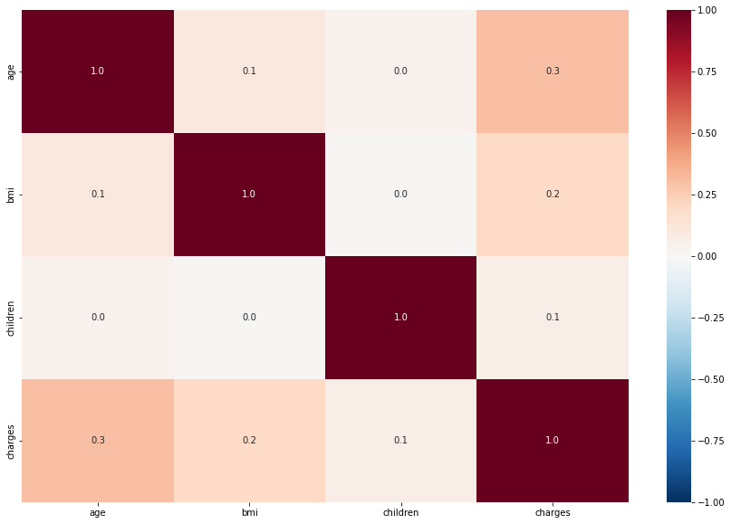

```python
# Create correlation matrix
corr_mat = data.corr()

# Plot heatmap
plt.figure(figsize=(15, 10))
sns.heatmap(corr_mat, annot=True, fmt='.1f',
            cmap='RdBu_r', vmin=-1, vmax=1)
```

### Charges

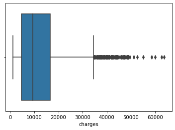

```python
sns.boxplot(data['charges'])
```

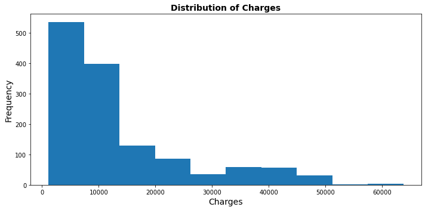

```python
plt.figure(figsize=[10, 5])
plt.hist(data.charges)
plt.title("Distribution of Charges", fontweight="bold", fontsize=14)
plt.xlabel("Charges", fontsize=14)
plt.ylabel("Frequency", fontsize=14)
plt.tight_layout()
```

The medical cost distribution chart is skewed to the right. The smallest fee is about 1122 and the highest is about 63770, the difference is huge, up to 62648.

### Smoker

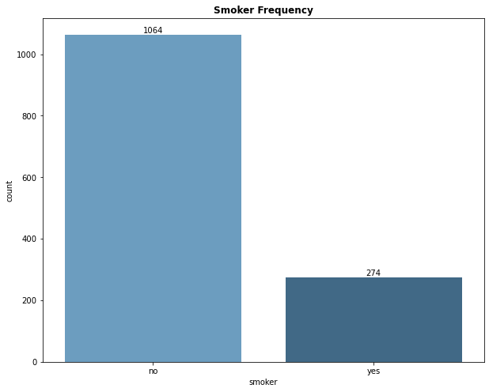

```python
plt.figure(figsize= [10, 8])
ax = sns.countplot(
    x="smoker",
    data=data,
    order=data.smoker.value_counts().index.values,
    palette="Blues_d",
)
ax.bar_label(ax.containers[0])
plt.title("Smoker Frequency", fontweight="bold")
```

Non-smokers (accounting for about 80% significantly more than smokers (accounting for about 20%) in the dataset.

[output not shown]

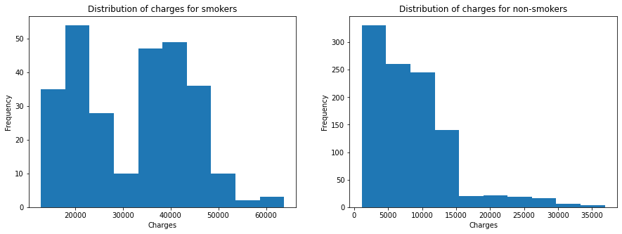

```python
#Smoker with charges
fig, (ax1, ax2) = plt.subplots(ncols = 2,
nrows = 1, figsize=(15,5))

ax1.hist(data[(data.smoker == 'yes')]["charges"])
ax1.set(title = 'Distribution of charges for smokers', xlabel = 'Charges', ylabel = 'Frequency')

ax2.hist(data[(data.smoker == 'no')]["charges"])
ax2.set(title = 'Distribution of charges for non-smokers', xlabel = 'Charges', ylabel = 'Frequency')
```

- The annual medical expenses of smokers range from 12829.46 to 63770.43
- Annual medical expenses for non-smokers range from 1121.87 to 36910.61 => Smokers pay much larger hospital bills than non-smokers although the number of smokers is significantly smaller than that of non-smokers, indicating that smoking has adverse health effects. However, there are some exceptions where non-smokers still have to pay quite high hospital fees, maybe they have other diseases.

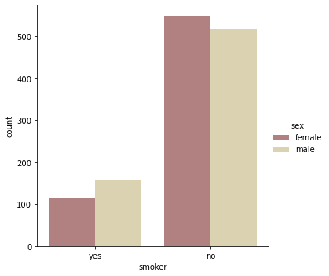

```python
ax = sns.catplot(x="smoker", kind="count",hue = 'sex', palette="pink", data=data)
```

[figure not shown]

[figure not shown]

```python
plt.figure(figsize=(12,5))
plt.title("Box plot for charges of women")
sns.boxplot(y="smoker", x="charges", data =  data[(data.sex == 'male')] , orient="h", palette = 'magma')


plt.figure(figsize=(12,5))
plt.title("Box plot for charges of men")
sns.boxplot(y="smoker", x="charges", data =  data[(data.sex == 'female')] , orient="h", palette = 'rainbow')
```

It can be seen that non-smokers both male and female have outliers. Both male and female smokers share a common pattern of fees, with no significant difference between the sexes.

### Age

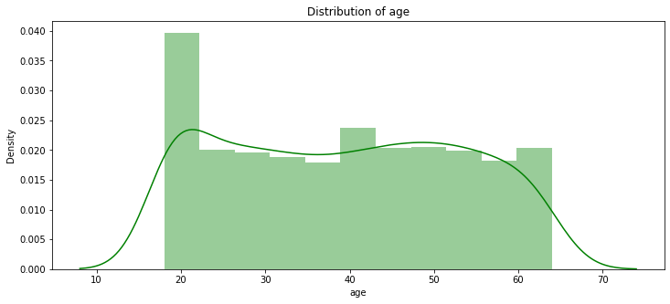

```python
#age with charges
plt.figure(figsize=(12,5))
plt.title("Distribution of age")
ax = sns.distplot(data["age"], color = 'g')
```

The age range is from 18 years old to 64 years old.

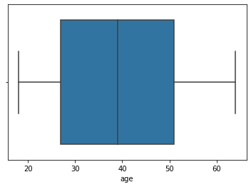

```python
sns.boxplot(data['age'])
```

```python
data['age_cat'] = np.nan
```

```python
data.loc[(data["age"] >= 18) & (data["age"] <= 35), 'age_cat'] = 'Young Adult'
data.loc[(data["age"] > 35) & (data["age"] <= 55), 'age_cat'] = 'Senior Adult'
data.loc[(data["age"] > 55), 'age_cat'] = 'Elder'
```

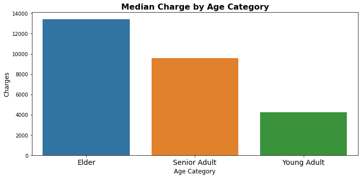

```python
plt.figure(figsize=[10, 5])
sns.barplot(
    x="age_cat",
    y="charges",
    order=data[["age_cat", "charges"]]
    .groupby("age_cat")
    .median()
    .sort_values(by="charges", ascending=False)
    .index.values,
    ci=None,
    estimator=np.median,
    data=data,
)
plt.title("Median Charge by Age Category", fontweight="bold", fontsize=16)
plt.xticks(fontsize=14)
plt.xlabel("Age Category", fontsize=12)
plt.ylabel("Charges", fontsize=12)
plt.tight_layout()
```

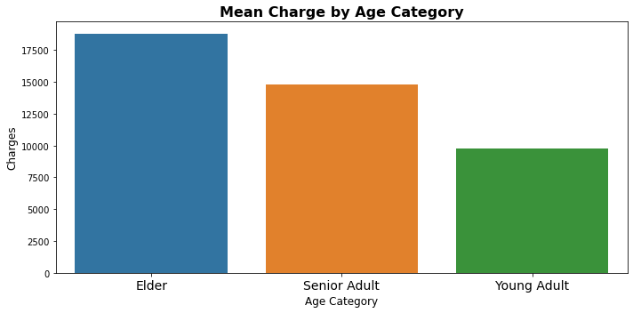

```python
plt.figure(figsize=[10, 5])
sns.barplot(
    x="age_cat",
    y="charges",
    order=data[["age_cat", "charges"]]
    .groupby("age_cat")
    .mean()
    .sort_values(by="charges", ascending=False)
    .index.values,
    ci=None,
    estimator=np.mean,
    data=data,
)
plt.title("Mean Charge by Age Category", fontweight="bold", fontsize=16)
plt.xticks(fontsize=14)
plt.xlabel("Age Category", fontsize=12)
plt.ylabel("Charges", fontsize=12)
plt.tight_layout()
```

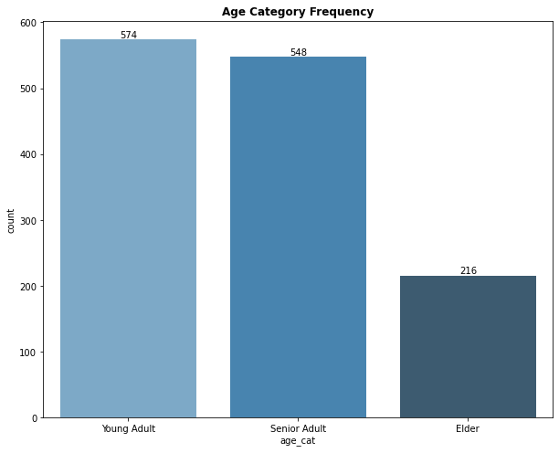

```python
plt.figure(figsize= [10, 8])
ax = sns.countplot(
    x="age_cat",
    data=data,
    order=data.age_cat.value_counts().index.values,
    palette="Blues_d",
)
ax.bar_label(ax.containers[0])
plt.title("Age Category Frequency", fontweight="bold")
```

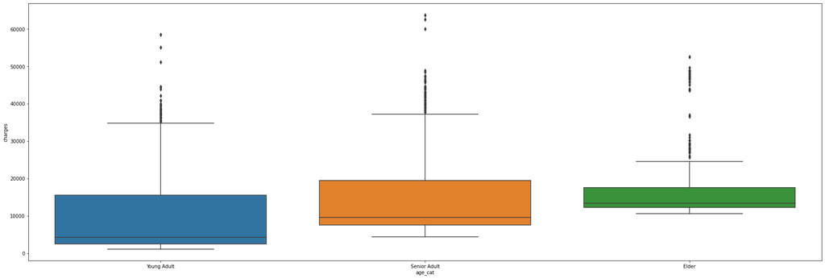

```python
plt.figure(figsize=(30,10))
sns.boxplot(data = data, x = 'age_cat', y = 'charges')
```

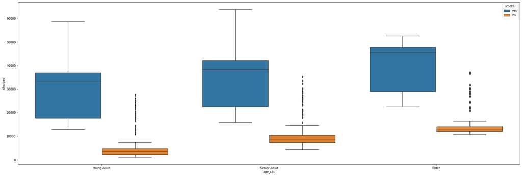

```python
plt.figure(figsize=(30,10))
sns.boxplot(data = data, x = 'age_cat', y = 'charges', hue = 'smoker')
```

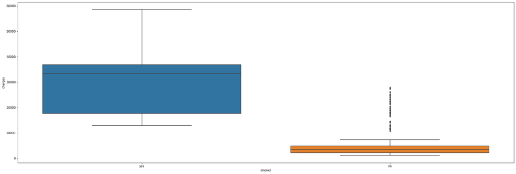

```python
plt.figure(figsize=(30,10))
sns.boxplot(data = data[(data.age_cat == 'Young Adult')], x = 'smoker', y = 'charges')
```

### BMI

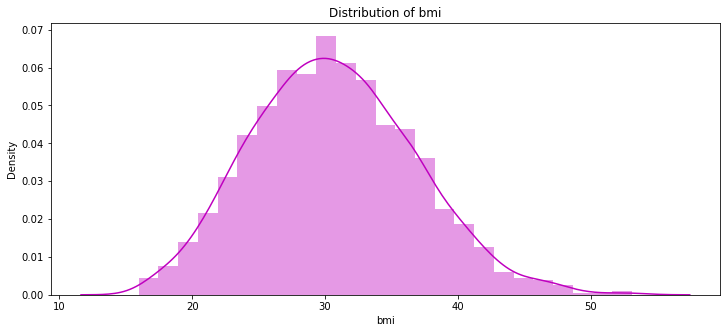

```python
plt.figure(figsize=(12,5))
plt.title("Distribution of bmi")
ax = sns.distplot(data["bmi"], color = 'm')
```

- Most BMI indexes are concentrated in the range of 27 - 33, the number of people with BMI 30 is the most equivalent to the level of obesity.
- The minimum BMI was 16 and the maximum was 53.1.
- The average BMI is 30.66, which is beyond the ideal BMI for the average person, from which it can be recognized that Americans are facing overweight that affects their health.

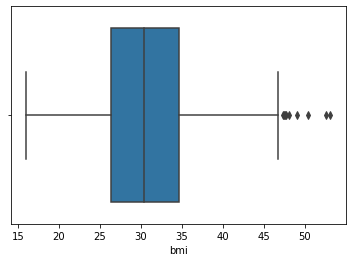

```python
sns.boxplot(data['bmi'])
```

```python
data["weight_condition"] = np.nan
```

```python
data.loc[data["bmi"] < 18, 'weight_condition'] = 'Underweight'
data.loc[(data["bmi"] >= 18.5) & (data["bmi"] < 24.986), 'weight_condition'] = 'Normal Weight'
data.loc[(data["bmi"] >= 25) & (data["bmi"] < 29.926), 'weight_condition'] = 'Overweight'
data.loc[(data["bmi"] >= 30), "weight_condition"] = "Obese"
```

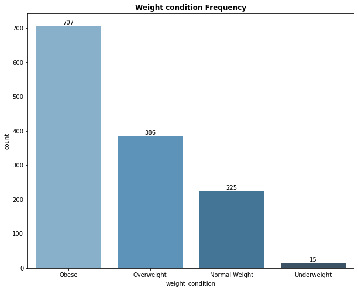

```python
plt.figure(figsize= [10, 8])
ax = sns.countplot(
    x="weight_condition",
    data=data,
    order=data.weight_condition.value_counts().index.values,
    palette="Blues_d",
)
ax.bar_label(ax.containers[0])
plt.title("Weight condition Frequency", fontweight="bold")
```

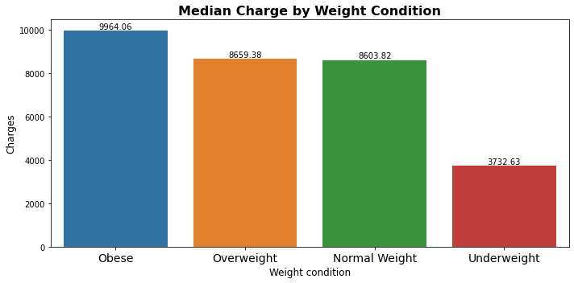

```python
plt.figure(figsize=[10, 5])
ax = sns.barplot(
    x="weight_condition",
    y="charges",
    order=data[["weight_condition", "charges"]]
    .groupby("weight_condition")
    .median()
    .sort_values(by="charges", ascending=False)
    .index.values,
    ci=None,
    estimator=np.median,
    data=data,
)
ax.bar_label(ax.containers[0])
plt.title("Median Charge by Weight Condition", fontweight="bold", fontsize=16)
plt.xticks(fontsize=14)
plt.xlabel("Weight condition", fontsize=12)
plt.ylabel("Charges", fontsize=12)
plt.tight_layout()
```

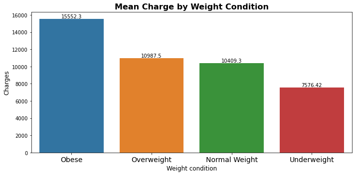

```python
plt.figure(figsize=[10, 5])
ax = sns.barplot(
    x="weight_condition",
    y="charges",
    order=data[["weight_condition", "charges"]]
    .groupby("weight_condition")
    .mean()
    .sort_values(by="charges", ascending=False)
    .index.values,
    ci=None,
    estimator=np.mean,
    data=data,
)
ax.bar_label(ax.containers[0])
plt.title("Mean Charge by Weight Condition", fontweight="bold", fontsize=16)
plt.xticks(fontsize=14)
plt.xlabel("Weight condition", fontsize=12)
plt.ylabel("Charges", fontsize=12)
plt.tight_layout()
```

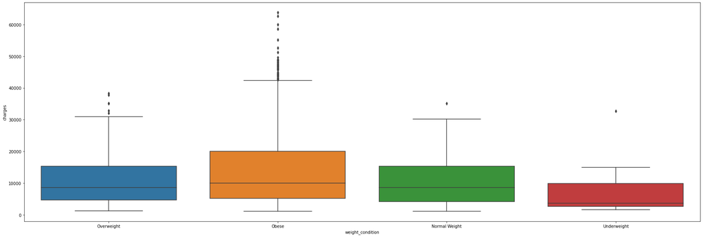

```python
plt.figure(figsize=(30,10))
sns.boxplot(data = data, x = 'weight_condition', y = 'charges')
```

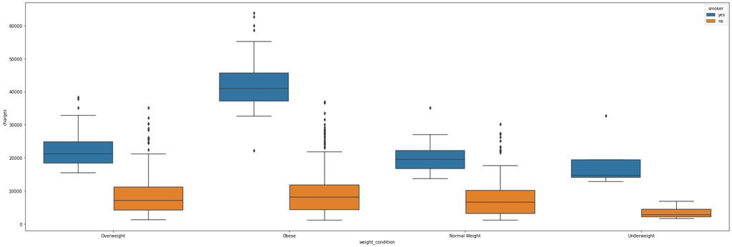

```python
plt.figure(figsize=(30,10))
sns.boxplot(data = data, x = 'weight_condition', y = 'charges', hue = 'smoker')
```

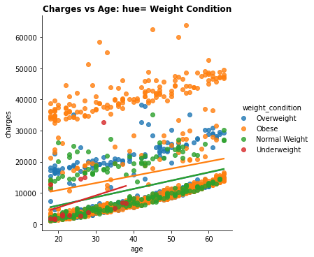

```python
sns.lmplot(x="age", y="charges", fit_reg=True, hue= 'weight_condition',ci= None, data=data)
plt.title("Charges vs Age: hue= Weight Condition", fontweight="bold")
```

It can be seen that all 4 groups have a positive relationship between charges and age. The older the age, the higher the charges to pay. The number of obese and overweight people accounts for most of the upper bound of the charges group. However, the obese group is also at the lower end of the charges group, which can be conjectured to be due to the concern for their own health or the income of this group of people.

### Region

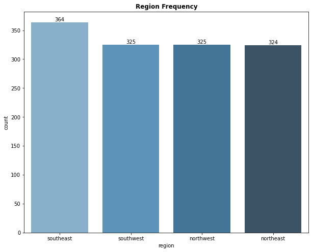

```python
plt.figure(figsize= [10, 8])
ax = sns.countplot(
    x="region",
    data=data,
    order=data.region.value_counts().index.values,
    palette="Blues_d",
)

ax.bar_label(ax.containers[0])
plt.title("Region Frequency", fontweight="bold")
```

The dataset is evenly distributed in 4 regions. Most of records are in the Southeast and the difference between regions is not significant.

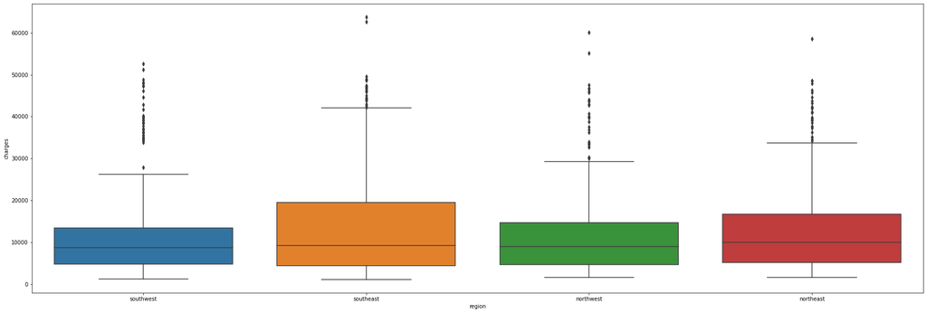

```python
plt.figure(figsize=(30,10))
sns.boxplot(data = data, x = 'region', y = 'charges')
```

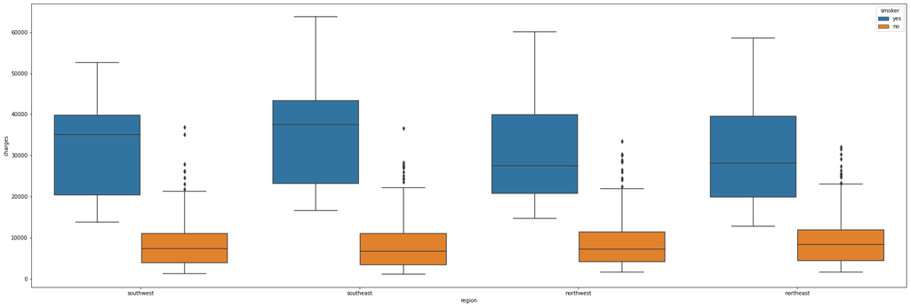

```python
plt.figure(figsize=(30,10))
sns.boxplot(data = data, x = 'region', y = 'charges', hue = 'smoker')
```

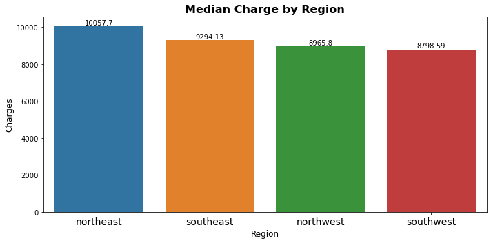

```python
plt.figure(figsize=[10, 5])
ax = sns.barplot(
    x="region",
    y="charges",
    order=data[["region", "charges"]]
    .groupby("region")
    .median()
    .sort_values(by="charges", ascending=False)
    .index.values,
    ci=None,
    estimator=np.median,
    data=data,
)
ax.bar_label(ax.containers[0])
plt.title("Median Charge by Region", fontweight="bold", fontsize=16)
plt.xticks(fontsize=14)
plt.xlabel("Region", fontsize=12)
plt.ylabel("Charges", fontsize=12)
plt.tight_layout()
```

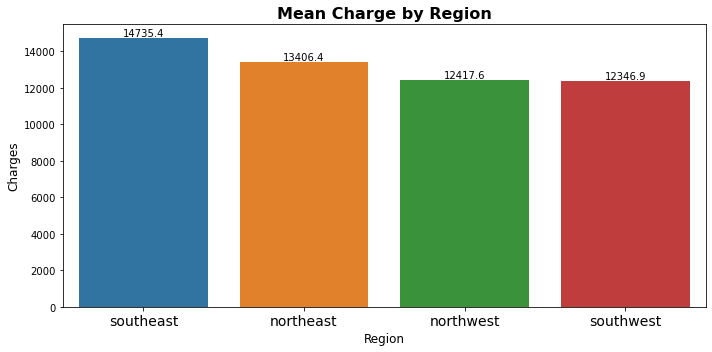

```python
plt.figure(figsize=[10, 5])
ax = sns.barplot(
    x="region",
    y="charges",
    order=data[["region", "charges"]]
    .groupby("region")
    .mean()
    .sort_values(by="charges", ascending=False)
    .index.values,
    ci=None,
    estimator=np.mean,
    data=data,
)
ax.bar_label(ax.containers[0])
plt.title("Mean Charge by Region", fontweight="bold", fontsize=16)
plt.xticks(fontsize=14)
plt.xlabel("Region", fontsize=12)
plt.ylabel("Charges", fontsize=12)
plt.tight_layout()
```

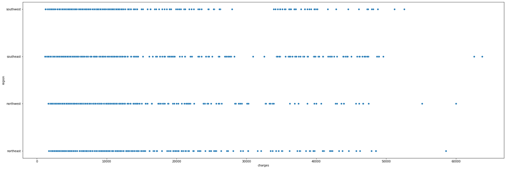

```python
plt.figure(figsize=(30,10))
sns.scatterplot(data = data, x = 'charges', y = 'region')
```

Most of the 4 regions have record centered around 1,500 to 15,500.

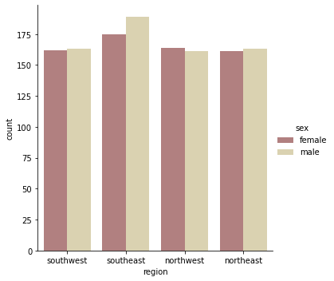

```python
x = sns.catplot(x="region", kind="count",hue = 'sex', palette="pink", data=data)
```

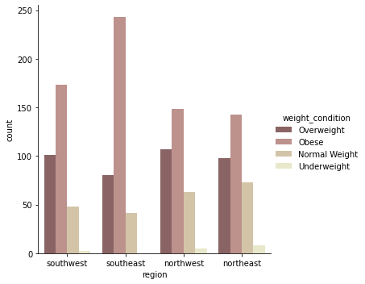

```python
ax = sns.catplot(x="region", kind="count",hue = 'weight_condition', palette="pink", data=data)
```

### Children

```python
data.loc[(data['children'] == 0), 'have_children'] = 0
data.loc[(data['children'] > 0), 'have_children'] = 1
```

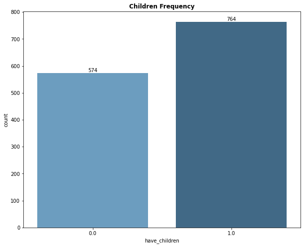

```python
plt.figure(figsize= [10, 8])
ax = sns.countplot(
    x="have_children",
    data=data,
    palette="Blues_d",
)
ax.bar_label(ax.containers[0])
plt.title("Children Frequency", fontweight="bold")
```

The number of people without children accounts for 43% in the dataset and the difference between the two groups is quite large.

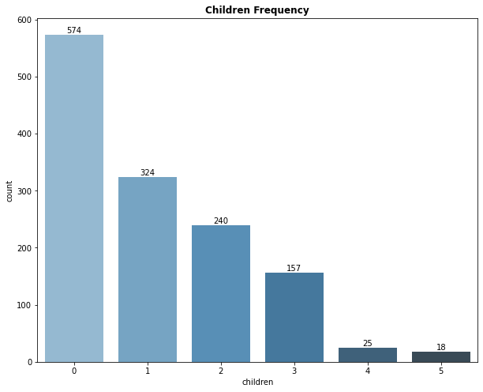

```python
plt.figure(figsize= [10, 8])
ax = sns.countplot(
    x="children",
    data=data,
    order=data.children.value_counts().index.values,
    palette="Blues_d",
)
ax.bar_label(ax.containers[0])
plt.title("Children Frequency", fontweight="bold")
```

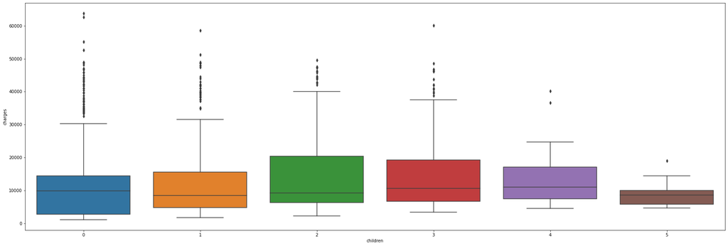

```python
plt.figure(figsize=(30,10))
ax = sns.boxplot(data = data, x = 'children', y = 'charges')
```

- Groups with children (0;1;3) have outliers at the top of charges, far away from the rest
- There isn't a big difference in media between the groups
- Highest IQR (representing the degree of fragmentation of the data set): group of 2 children
- Lowest IQR: group of 5 children

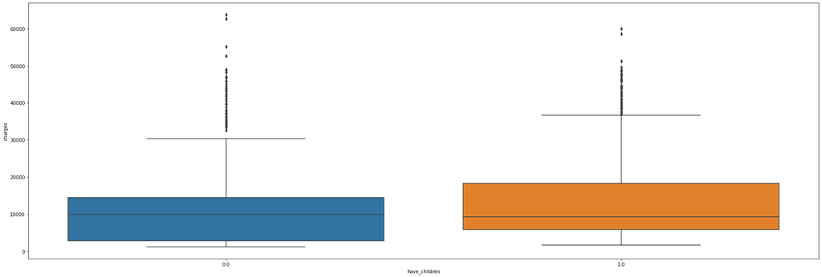

```python
plt.figure(figsize=(30,10))
ax = sns.boxplot(data = data, x = 'have_children', y = 'charges')
```

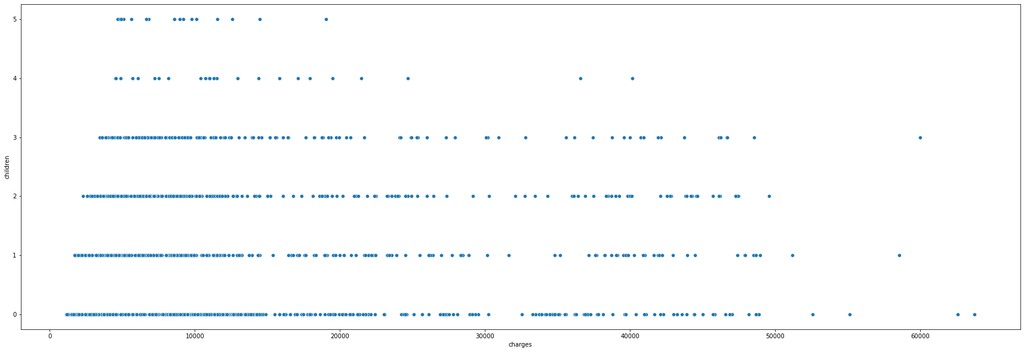

```python
plt.figure(figsize=(30,10))
sns.scatterplot(data = data, x = 'charges', y = 'children')
```

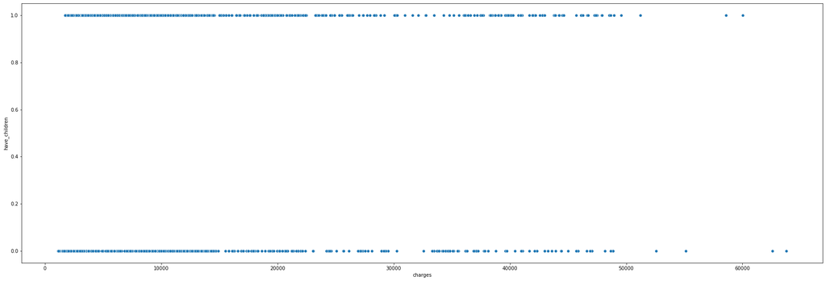

```python
plt.figure(figsize=(30,10))
sns.scatterplot(data = data, x = 'charges', y = 'have_children')
```